# 🏗️ House Construction Management App

Complete Architecture Documentation

app_complete.R (507 lines) + 17 R Modules (4,101 lines) | Last Updated: January 31, 2026

# Overview

### 📱 App Information

- **Main File:** app_complete.R (507 lines)
- **R Modules:** 17 files (4,101 lines)
- **Total Code:** 4,608 lines
- **Framework:** R Shiny Dashboard with Modular Architecture
- **Purpose:** Advanced house construction management with multi-floor planning, state management, and AI integration
- **Status:** Production Ready - Phase 5 Complete ✅

## Key Statistics

R FILES

18

Modular Components

MODULES

UI + Server Modules

CORE SYSTEMS

Config, AI, State, etc.

DATA STORES

7

Reactive Values

OUTPUTS

25+

Charts & Tables

## Architecture Layers

```
┌─────────────────────────────────────────────────┐
│         USER INTERFACE (9 Modules)              │
│  Dashboard, Site, Architecture, Budget, etc.    │
├─────────────────────────────────────────────────┤
│       SERVER LOGIC (Event Handlers)             │
│  observeEvent() handlers for user actions       │
├─────────────────────────────────────────────────┤
│     PROCESSING (27+ Functions)                  │
│  Calculations, Analysis, Helper Functions       │
├─────────────────────────────────────────────────┤
│      DATA STORAGE (Reactive Values)             │
│  Site, Rooms, Materials, Tasks, etc.            │
├─────────────────────────────────────────────────┤
│        OUTPUTS (Rendering)                      │
│  Plotly charts, Leaflet maps, DT tables         │
└─────────────────────────────────────────────────┘
```

## Color Coding in Diagrams

**Red/Pink:** Entry points, External files

**Blue:** UI Components, Modules

**Yellow:** Server Logic, Decisions

**Green:** Functions, Processing

**Purple:** Data Storage

**Orange:** Outputs, Rendering

# System Architecture

## Application Entry Point

The application starts in `app_complete.R` with the following modular initialization sequence:

```
# 1. Load Required Libraries (lines 6-14)
library(shiny)           # Web application framework
library(shinydashboard)  # Dashboard components
library(shinyjs)         # JavaScript interactions
library(DT)              # Interactive tables
library(plotly)          # Interactive charts
library(dplyr)           # Data manipulation
library(tidyr)           # Data tidying
library(jsonlite)        # JSON import/export
library(leaflet)         # Interactive maps

# 2. Source Core Systems (lines 17-21)
source("R/config.R")              # Configuration management
source("R/ai_integration.R")      # AI features (Ollama integration)
source("R/validation.R")          # Input validation
source("R/calculations.R")        # Mathematical calculations
source("R/analysis.R")            # Site and analysis functions

# 3. Source UI Modules (lines 24-31)
source("R/module_site_planning.R")     # Site planning module
source("R/module_architecture.R")      # Architecture & floor planning
source("R/module_budget_materials.R")  # Budget & materials
source("R/module_plumbing.R")          # Plumbing systems
source("R/module_electrical.R")        # Electrical systems
source("R/module_timeline.R")          # Project timeline
source("R/module_landscaping.R")       # Landscaping & eco
source("R/module_reports.R")           # Report generation

# 4. Source State Management (lines 29-33)
source("R/state_management.R")    # Centralized state management
source("R/persistence.R")         # Save/Load functionality
source("R/state_validation.R")    # State validation
source("R/session_management.R")  # Session handling

# 5. Get Configuration (line 36)
config <- get_config()

# 6. Create UI Structure (lines 42-213)
ui <- dashboardPage(...)

# 7. Define Server Logic (lines 215-507)
server <- function(input, output, session) { ... }

# 8. Run Application (line 507)
shinyApp(ui = ui, server = server)
```

## Layer 1: UI Structure

### Dashboard Header

```
dashboardHeader(
  title = "House Construction Manager",
  titleWidth = 300
)
```

**Purpose:** Main navigation bar at the top of the application

### Sidebar Menu - 9 Navigation Items

1. 📊 Dashboard - Project overview
2. 🗺️ Site Planning - Maps & analysis
3. 🏛️ Architecture - Room design
4. 💰 Budget & Materials - Cost tracking
5. 🚰 Plumbing System - Water management
6. ⚡ Electrical System - Load & solar
7. 📅 Timeline & Tasks - Gantt charts
8. 🌿 Landscaping & Eco - Sustainability
9. 📄 Reports - Documentation

## Layer 2: Server Logic

### Event-Driven Architecture

The server uses Shiny's reactive programming model:

1. **User Action** → Triggers event (button click, input change)
2. **observeEvent()** → Captures the event
3. **Processing** → Calls calculation/analysis functions
4. **Update** → Modifies reactive values
5. **Re-render** → Outputs automatically update

## Layer 4: Data Storage

### Reactive Values Store

All application state is stored in a reactive values object:

```
rv <- reactiveValues(
  site_data = list(),      # Site configuration and analysis
  rooms = data.frame(),    # Room details and dimensions
  materials = data.frame(), # Materials with costs and eco-scores
  tasks = data.frame(),    # Timeline tasks and progress
  plumbing = list(),       # Plumbing configuration
  electrical = list(),     # Electrical configuration
  eco_features = list()    # Landscaping and eco features
)
```

**Why Reactive Values?**

- ✅ Single source of truth
- ✅ Automatic dependency tracking
- ✅ Efficient re-rendering (only affected outputs update)
- ✅ Easy to debug and inspect

# Modules

The application consists of **9 integrated modules**, each serving a specific purpose in the construction management workflow.

| Module | Icon | Purpose | Key Features |
| --- | --- | --- | --- |
| **1. Dashboard** | 📊 | Project overview with KPIs and metrics | Value boxes, charts, statistics table |
| **2. Site Planning** | 🗺️ | Advanced site planning with terrain elevation, drainage paths, slope analysis | 3D terrain visualization, boundary editor, climate/soil/water flow/gravity analysis |
| **3. Architecture** | 🏛️ | Advanced multi-floor planning with drag-and-drop, Vaastu analysis | Fabric.js canvas, multi-floor support, 2D/3D views, boundary overlays |
| **4. Budget & Materials** | 💰 | Material management, cost tracking, eco-scoring | Material table, cost charts, eco-score visualization |
| **5. Plumbing System** | 🚰 | Water management, rainwater harvesting, drainage | Tank capacity, pipe calculations, water network chart |
| **6. Electrical System** | ⚡ | Load calculation, solar integration, battery storage | Load distribution, solar vs grid analysis |
| **7. Timeline & Tasks** | 📅 | Task management, Gantt charts, progress tracking | Task table, Gantt chart, status tracking |
| **8. Landscaping & Eco** | 🌿 | Permaculture, food forest, sustainability metrics | Tree management, sustainability radar chart |
| **9. Reports** | 📄 | Report generation and documentation | Selectable sections, HTML download |

## Module Example: Architecture 🏛️

### Purpose

Advanced multi-floor planning with drag-and-drop room design, Vaastu compliance, and visual 2D/3D representation

### Features

1. **Multi-Floor Support** - Ground floor, first floor, second floor, with ability to add more
2. **Drag-and-Drop Interface** - Canvas-based room placement using Fabric.js
3. **Room Type Library** - 20+ pre-defined room types (living, bedrooms, kitchen, etc.)
4. **Boundary Overlays** - Show plot, site, house compound, and neighbor boundaries
5. **Vaastu Analysis** - Real-time compliance checking with directional recommendations
6. **2D/3D Views** - Toggle between floor plan and 3D model views
7. **Material Calculation** - Automatic concrete/steel/brick calculation per floor
8. **Compass Overlay** - Directional guidance for Vaastu placement

### Data Flow

```
User enters room details
  ↓
Click "Add Room"
  ↓
Vaastu check (favorable/unfavorable)
  ↓
Calculate materials (concrete, steel, bricks)
  ↓
Add to rv$rooms
  ↓
Render room table and floor plan
  ↓
Auto-add materials to budget module
```

# Functions

The application uses **27+ functions** organized into three categories:

1. **Calculation Functions (9)** - Pure mathematical calculations
2. **Analysis Functions (7)** - Complex site and system analysis
3. **Helper Functions (11+)** - Support and utility functions

## Key Calculation Functions (6 Core)

### 1. calculate_concrete_volume(length, width, thickness)

**Purpose:** Calculate concrete volume for slabs, foundations

**Formula:** `Volume = length × width × thickness`

**Output:** Volume in cubic meters (m³)

### 2. calculate_steel_quantity(concrete_volume, steel_percentage)

**Purpose:** Calculate steel reinforcement needed

**Formula:** `Steel (kg) = volume × (percentage/100) × 7850 kg/m³`

**Default:** 1.5% steel ratio for residential construction

### 3. calculate_bricks(length, width, height, wall_thickness)

**Purpose:** Calculate number of bricks for walls

**Formula:** `Wall area × 57 bricks/m² (for 230mm wall)`

**Standard brick:** 190mm × 90mm × 90mm with mortar

### 4. calculate_pipe_length(num_points, avg_distance)

**Purpose:** Estimate plumbing pipe requirements

**Formula:** `Length = num_points × avg_distance × 1.2`

**Includes:** 20% extra for routing and fittings

### 5. calculate_electrical_load(lights, fans, ac_units, appliances)

**Purpose:** Calculate total electrical load

**Formula:**

```
Load = (lights × 20W) + (fans × 75W) + (ac_units × 1500W) + (appliances × 200W)
```

**Output:** Total load in Watts (W)

### 6. calculate_eco_score(recycled_content, local_source, renewable)

**Purpose:** Rate material sustainability

**Formula:** `Score = (recycled × 0.4) + (local × 0.3) + (renewable × 0.3)`

**Output:** Score from 0-100

**Purpose:** Classify soil type and provide recommendations

**Output includes:**

- Primary soil type
- Bearing capacity
- Foundation recommendation
- Soil preparation steps
- Suitability score

### 4. elevation_analysis(boundary_coords, lat, lon)

**Purpose:** Generate terrain elevation model and analyze slopes

**Output includes:**

- 3D terrain surface
- Elevation range (min/max)
- Slope percentages
- High and low points
- Topography classification

### 5. water_flow_analysis(boundary_coords, neighboring_coords, lat, lon)

**Purpose:** Analyze water drainage patterns and flow direction

**Analyzes:**

- Natural drainage paths
- Water accumulation zones
- Flow direction from neighbors
- Potential flooding areas
- Drainage system recommendations

### 6. gravity_system_analysis(boundary_coords, lat, lon)

**Purpose:** Evaluate gravity-fed water and drainage feasibility

**Determines:**

- Optimal tank placement locations
- Gravity-fed system viability
- Pressure calculations
- Pump requirements

### 7. comprehensive_site_analysis(boundary_coords, neighboring_coords, lat, lon)

**Purpose:** Complete integrated site assessment

**Combines all analyses:**

- Climate and soil analysis
- Elevation and topography
- Water flow patterns
- Gravity system feasibility
- Overall site suitability score
- Comprehensive recommendations

**Additional specialized functions include:**

# Data Flow

## Data Flow Overview

```
USER INPUT → VALIDATION → PROCESSING → STORAGE → REACTIVITY → RENDERING → DISPLAY
```

## Pattern 1: User Input to Display

### Example: Adding a Room

1. **Input:** User fills room form (name, dimensions, direction)
2. **Trigger:** User clicks "Add Room" button
3. **Event:** `observeEvent(input$add_room)` fires
4. **Validation:** Check for required fields
5. **Processing:**
   - Run `vaastu_analysis(room_type, direction)`
   - Call `calculate_concrete_volume(L, W, thickness)`
   - Call `calculate_steel_quantity(concrete_volume)`
   - Call `calculate_bricks(L, W, H)`
6. **Storage:** Add room and materials to `rv$rooms` and `rv$materials`
7. **Reactivity:** Reactive expressions detect changes
8. **Rendering:** Tables and charts update
9. **Display:** User sees updated content

## Pattern 2: Cascade Calculations

### Example: Room → Materials → Budget

```
User adds room in Architecture module
  ↓
Calculate room area = L × W
  ↓
Auto-calculate materials:
  ├─ Concrete = calculate_concrete_volume()
  ├─ Steel = calculate_steel_quantity()
  └─ Bricks = calculate_bricks()
  ↓
Add materials to rv$materials
  ↓
Budget module automatically updates:
  ├─ Materials table
  ├─ Cost chart
  └─ Eco-score chart
```

This demonstrates **cross-module data flow** and **automatic updates**.

## Data Storage Structure

| Store | Type | Contents |
| --- | --- | --- |
| `rv$site_data` | List | Units, area, orientation, boundaries, analysis results |
| `rv$rooms` | Data Frame | Room name, L/W/H, direction, area, Vaastu status |
| `rv$materials` | Data Frame | Material name, quantity, unit, cost, eco-score |
| `rv$tasks` | Data Frame | Task name, start/end dates, status, progress |
| `rv$plumbing` | List | Tank capacity, RWH, bathrooms, kitchens, grey water |
| `rv$electrical` | List | Lights, fans, AC, appliances, solar, battery |
| `rv$eco_features` | List | Trees, ponds, livestock, composting, biogas |

# Decision Logic

## Decision Tree 1: Vaastu Analysis

```
INPUT: Room Type + Direction
  ↓
Is this combination in the favorable list?
  ├─ YES
  │   ↓
  │   Return: "✓ Favorable placement"
  │   Status: "success"
  │
  └─ NO
      ↓
      Return: "⚠ Unfavorable placement"
      Status: "warning"
      Recommendation: Suggest favorable directions
```

## Decision Tree 2: Slope Analysis

```
Calculate Slope Percentage
  ↓
  ├─ Slope > 5%?
  │   └─ YES → "Challenging" + terracing required
  │
  ├─ Slope 2-5%?
  │   └─ YES → "Good" + good natural drainage
  │
  └─ Slope < 2%?
      └─ YES → "Excellent" + artificial drainage needed
```

## Decision Tree 3: Solar Sufficiency

```
Calculate Daily Energy Requirement
Calculate Solar Daily Production
  ↓
Solar Production ≥ Daily Requirement?
  ├─ YES → "✓ Self-Sufficient"
  │         Grid Required: 0%
  │
  └─ NO → Calculate Deficit
          Grid Requirement = (Deficit / Requirement) × 100%

          ├─ < 25% → "Mostly Self-Sufficient"
          ├─ 25-50% → "Partial Grid Dependency"
          └─ > 50% → "High Grid Dependency"
```

# Technology Stack

## Core R Packages

| Package | Version | Purpose |
| --- | --- | --- |
| `shiny` | ≥ 1.7.0 | Web application framework |
| `shinydashboard` | ≥ 0.7.0 | Dashboard components and layout |
| `plotly` | Latest | Interactive charts and visualizations |
| `leaflet` | Latest | Interactive maps |
| `jsonlite` | Latest | JSON import/export for project save/load |
| `htmlwidgets` | Latest | Enhanced HTML widgets and JavaScript bindings |
| `DT` | Latest | Interactive, sortable data tables |
| `dplyr` | Latest | Data manipulation |
| `tidyr` | Latest | Data tidying |

## Frontend Enhancement Files

| File | Type | Purpose |
| --- | --- | --- |
| `www/boundary_editor.js` | JavaScript | Interactive boundary coordinate editing |
| `www/floorplan.js` | JavaScript | Floor plan canvas with Fabric.js |
| `www/floorplan.css` | CSS | Custom styling for floor plan interface |
| `Fabric.js 5.3.0` | JavaScript Library (CDN) | Canvas-based drag-and-drop floor plan editor |

## Development Tools

### Development Environment

- **IDE:** RStudio (recommended)
- **Version Control:** Git
- **Deployment:** Shiny Server / shinyapps.io
- **Testing:** Manual testing + test scripts (test_ai_setup.R, etc.)
- **Documentation:** R Markdown

# Visual Diagrams

The following static images show the complete architecture. They are generated from Python scripts and can be regenerated anytime the app structure changes.

## 1. Complete Architecture Flowchart

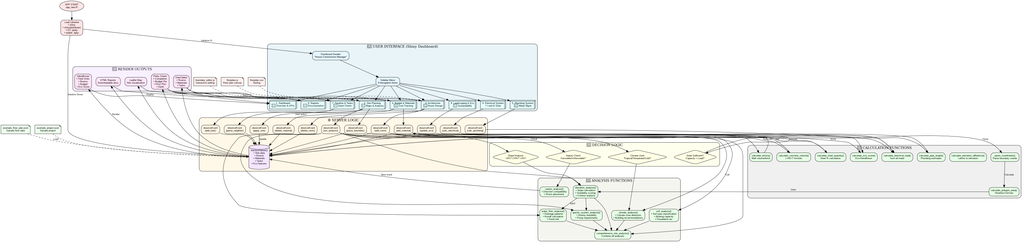

**Shows:** Complete app architecture with all modules, functions, server logic, data flow, and connections.

**Use for:** Understanding the complete system, identifying integration points, debugging complex issues.

## 2. Module Detailed Flow

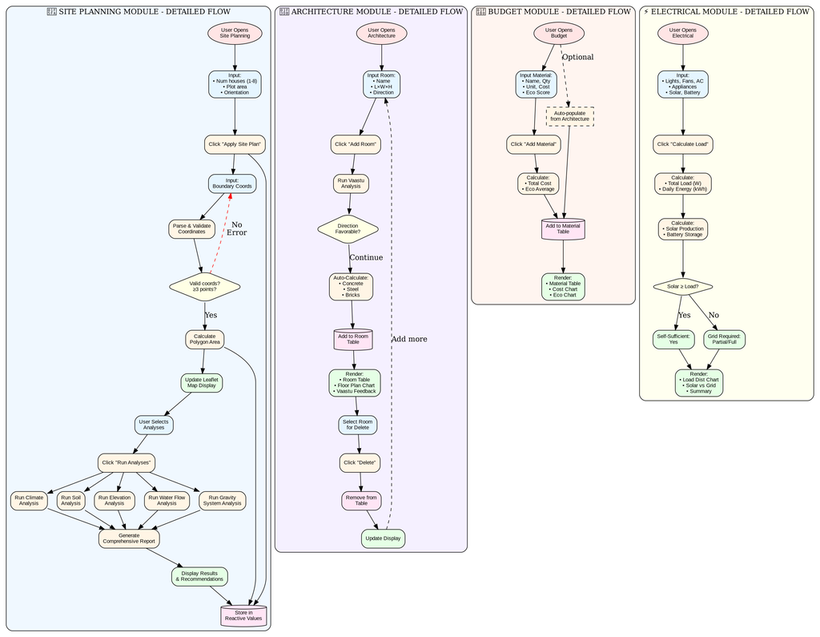

**Shows:** Step-by-step workflows for Site Planning, Architecture, Budget, and Electrical modules.

**Use for:** Understanding module internals, implementing new features, troubleshooting.

## 3. Data Flow Diagram

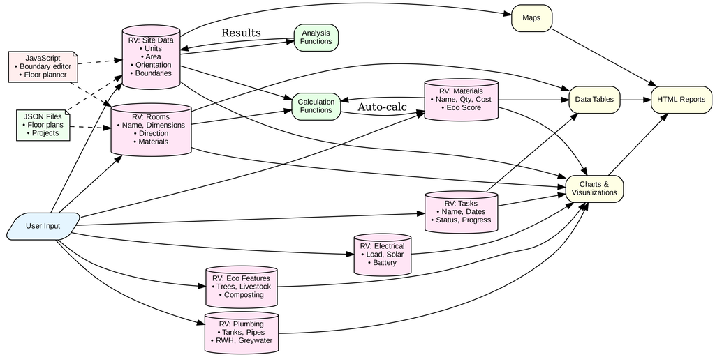

**Shows:** Data sources, reactive value stores, processing pipeline, and outputs.

**Use for:** Understanding state management, optimizing data flow, debugging reactive issues.

## Regenerate Diagrams

To regenerate these diagrams after app changes:

```
# Generate static diagrams
python create_architecture_flowchart.py

# Generate animated GIF
python create_animated_flowchart.py
```

# 📈 Scalability Assessment

**Purpose:** This guide provides a comprehensive scalability analysis of the application and a roadmap for making it easily extensible without major restructuring.

**Target:** Developers who need to add features, refactor code, or scale the application for production use.

## Current Architecture Analysis

### 📊 Application Metrics (Current - Phase 5)

4,608

Lines of Code

18

Modular R Files

9

UI Modules

Core Systems

✅

State Management

✅

AI Integration

### 🏗️ Current Architecture Pattern ✅

#### Modular Architecture (Phase 5 Complete)

**Current Structure:**

```
app_complete.R (507 lines)
├── Library Imports (lines 6-14)
├── Core Systems (lines 17-21)
│   ├── R/config.R - Configuration
│   ├── R/ai_integration.R - AI features
│   ├── R/validation.R - Validation
│   ├── R/calculations.R - Calculations
│   └── R/analysis.R - Analysis
├── UI Modules (lines 24-31)
│   ├── R/module_site_planning.R
│   ├── R/module_architecture.R
│   ├── R/module_budget_materials.R
│   ├── R/module_plumbing.R
│   ├── R/module_electrical.R
│   ├── R/module_timeline.R
│   ├── R/module_landscaping.R
│   └── R/module_reports.R
├── State Management (lines 29-33)
│   ├── R/state_management.R - Centralized state
│   ├── R/persistence.R - Save/Load
│   ├── R/state_validation.R - Validation
│   └── R/session_management.R - Sessions
├── UI Definition (lines 42-213)
└── Server Logic (lines 215-507)
```

## Scalability Achievements 🎉

### ✅ Issues Resolved (Phase 5 Complete)

#### 1. Modular Architecture ✅ COMPLETE

**Previous Impact:** HIGH | **Current Status:** RESOLVED

- **Previous Problem:** All 5,115 lines in single file
- **Solution Implemented:** Split into 18 modular R files
- **Current State:** app_complete.R (507) + 17 modules (4,101)
- **Benefits:** Easy collaboration, clear code ownership, simple debugging

#### 2. Loose Coupling ✅ COMPLETE

**Previous Impact:** HIGH | **Current Status:** RESOLVED

#### 3. No Automated Testing

**Impact:** MEDIUM | **Effort to Fix:** MEDIUM

- **Problem:** Pure functions exist but no test suite
- **Risk:** Regression bugs when refactoring
- **Current State:** Manual testing only
- **Recommendation:** Add testthat suite for calculation/analysis functions

### 🟡 Medium Priority Issues

#### 4. Frontend-Backend Coupling

**Impact:** MEDIUM | **Effort to Fix:** LOW

- **Problem:** JavaScript directly sends data via `Shiny.setInputValue`
- **Risk:** Hard to change data structures without coordinating both sides
- **Current State:** Direct coupling in floorplan.js and boundary_editor.js
- **Recommendation:** Define clear API contract with validation

#### 5. Configuration Hardcoding

**Impact:** LOW | **Effort to Fix:** LOW

#### 6. State Management Complexity

**Impact:** MEDIUM | **Effort to Fix:** LOW

## Refactoring Roadmap

### 🎯 Guiding Principles

- ✅ **Incremental:** Make small, testable changes
- ✅ **Non-Breaking:** Keep existing functionality working
- ✅ **Backwards Compatible:** Support existing project files
- ✅ **Testable:** Each step should be independently verifiable
- ✅ **Documented:** Update this file after each phase

### Phase 1: Extract Configuration (1-2 days)

#### Goal: Centralize all configuration in reusable modules

**Step 1.1: Create R/config.R**

```
R/
└── config.R

# Room type definitions
ROOM_TYPES <- list(
  living_spaces = list(
    living_room = list(
      name = "Living Room",
      icon = "🛋️",
      color = "#FFE4B5",
      default_dims = list(length = 6, width = 5, height = 3),
      vaastu = c("North", "East", "Northeast")
    ),
    # ... more types
  ),
  bedrooms = list(...),
  functional = list(...)
)

# Vaastu rules
VAASTU_RULES <- list(
  "Living Room" = c("North", "East", "Northeast"),
  "Bedroom" = c("South", "Southwest", "West"),
  # ... more rules
)

# Material costs
MATERIAL_COSTS <- list(
  concrete = 6000,  # per m³
  steel = 60,       # per kg
  bricks = 8        # per piece
)

# Export as named list
get_config <- function() {
  list(
    room_types = ROOM_TYPES,
    vaastu_rules = VAASTU_RULES,
    material_costs = MATERIAL_COSTS
  )
}
```

**Step 1.2: Update app.R to source config**

```
source("R/config.R")
config <- get_config()

# Replace hardcoded values
vaastu_rules <- config$vaastu_rules  # instead of hardcoding in function
```

**Step 1.3: Create www/config.js**

```
// Room type configuration
const ROOM_CONFIG = {
  living_room: {
    name: "Living Room",
    icon: "🛋️",
    color: "#FFE4B5"
  },
  // ... more types
};

// Export for use in other JS files
window.ROOM_CONFIG = ROOM_CONFIG;
```

**✅ Verification:**

- App runs without errors
- Room types work correctly
- Vaastu analysis produces same results
- Floor plan colors match

### Phase 2: Extract Pure Functions (2-3 days)

#### Goal: Separate business logic from UI code

**Step 2.1: Create R/calculations.R**

```
R/
├── config.R
└── calculations.R

# Move all calculation functions
calculate_concrete_volume <- function(length, width, thickness) { ... }
calculate_steel_quantity <- function(concrete_volume, steel_percentage = 1.5) { ... }
calculate_bricks <- function(length, width, height, wall_thickness = 0.23) { ... }
calculate_pipe_length <- function(num_points, avg_distance = 3) { ... }
calculate_electrical_load <- function(lights, fans, ac_units, appliances) { ... }
calculate_eco_score <- function(recycled_content, local_source, renewable) { ... }
```

**Step 2.2: Create R/analysis.R**

```
R/
├── config.R
├── calculations.R
└── analysis.R

# Move all analysis functions
vaastu_analysis <- function(room_type, direction) { ... }
climate_analysis <- function(lat, lon) { ... }
soil_analysis <- function(lat, lon, climate_zone) { ... }
elevation_analysis <- function(boundary_coords, lat, lon) { ... }
water_flow_analysis <- function(boundary_coords, neighboring_coords, lat, lon) { ... }
gravity_system_analysis <- function(boundary_coords, lat, lon) { ... }
comprehensive_site_analysis <- function(boundary_coords, neighboring_coords, lat, lon) { ... }
```

**Step 2.3: Create R/ai_integration.R**

```
R/
├── config.R
├── calculations.R
├── analysis.R
└── ai_integration.R

# Move AI functions
call_ollama <- function(prompt, model = "llama3.1:8b") { ... }
call_groq <- function(prompt, model = "llama-3.1-70b-versatile") { ... }
call_ai <- function(prompt, context = NULL) { ... }
```

**Step 2.4: Update app.R**

```
# Source all utility modules
source("R/config.R")
source("R/calculations.R")
source("R/analysis.R")
source("R/ai_integration.R")

# app.R now contains only:
# - UI definition
# - Server function
# - Reactive logic
```

**✅ Verification:**

- All calculations work correctly
- AI integration still functional
- Site analysis produces same results
- app.R reduced by ~500 lines

### Phase 3: Create Shiny Modules (1 week)

#### Goal: Break monolithic UI/server into independent modules

**Step 3.1: Create module structure**

```
R/
├── config.R
├── calculations.R
├── analysis.R
├── ai_integration.R
└── modules/
    ├── concept_module.R
    ├── architecture_module.R
    ├── budget_module.R
    ├── plumbing_module.R
    ├── electrical_module.R
    ├── timeline_module.R
    ├── report_module.R
    ├── analysis_module.R
    └── chat_module.R
```

**Step 3.2: Example Architecture Module**

```
# R/modules/architecture_module.R

# UI Function
architectureUI <- function(id) {
  ns <- NS(id)

  tabItem(
    tabName = "architecture",
    h2("Architecture & Room Design"),

    fluidRow(
      # Floor Planning Interface
      box(
        title = "Room Types",
        width = 2,
        # ... UI content
      ),

      box(
        title = "Floor Plan Canvas",
        width = 7,
        # ... canvas UI
      ),

      box(
        title = "Room Properties",
        width = 3,
        # ... properties UI
      )
    ),

    fluidRow(
      box(
        title = "Room List",
        width = 12,
        DTOutput(ns("room_table"))
      )
    )
  )
}

# Server Function
architectureServer <- function(id, rv, session_main) {
  moduleServer(id, function(input, output, session) {

    # Module-specific reactive values
    local_rv <- reactiveValues(
      selected_room_id = NULL,
      canvas_initialized = FALSE
    )

    # Add room event
    observeEvent(input$add_room_canvas, {
      req(input$room_name_canvas)

      # Validate inputs
      # ... validation logic

      # Add to shared rv
      new_room <- data.frame(...)
      rv$rooms <- rbind(rv$rooms, new_room)

      # Send to canvas
      session_main$sendCustomMessage("add_room", room_data)
    })

    # Render room table
    output$room_table <- renderDT({
      rv$rooms %>%
        filter(Floor == rv$current_floor) %>%
        datatable(...)
    })

    # Return module interface (optional)
    return(list(
      get_rooms = reactive({ rv$rooms }),
      clear_selection = function() { local_rv$selected_room_id <- NULL }
    ))
  })
}
```

```
# Source modules
source("R/modules/architecture_module.R")
source("R/modules/budget_module.R")
# ... source all modules

ui <- dashboardPage(
  dashboardHeader(...),
  dashboardSidebar(...),
  dashboardBody(
    tabItems(
      # Use module UI functions
      architectureUI("architecture"),
      budgetUI("budget"),
      plumbingUI("plumbing"),
      # ... other modules
    )
  )
)

server <- function(input, output, session) {
  # Shared reactive values
  rv <- reactiveValues(...)

  # Call module servers
  architectureServer("architecture", rv, session)
  budgetServer("budget", rv, session)
  plumbingServer("plumbing", rv, session)
  # ... other modules
}
```

**✅ Verification:**

### Phase 4: Add Testing Infrastructure (3-4 days)

#### Goal: Ensure code quality and catch regressions

**Step 4.1: Set up testthat**

```
tests/
├── testthat/
│   ├── test-calculations.R
│   ├── test-analysis.R
│   ├── test-config.R
│   └── test-modules.R
└── testthat.R
```

**Step 4.2: Example test file**

```
# tests/testthat/test-calculations.R

test_that("calculate_concrete_volume works correctly", {
  # Test normal case
  volume <- calculate_concrete_volume(10, 5, 0.15)
  expect_equal(volume, 7.5)

  # Test with NA
  volume_na <- calculate_concrete_volume(NA, 5, 0.15)
  expect_equal(volume_na, 0)

  # Test zero dimensions
  volume_zero <- calculate_concrete_volume(0, 5, 0.15)
  expect_equal(volume_zero, 0)
})

test_that("calculate_steel_quantity works correctly", {
  steel <- calculate_steel_quantity(10, 1.5)
  expected <- 10 * 0.015 * 7850
  expect_equal(steel, expected)
})

test_that("calculate_eco_score calculation", {
  score <- calculate_eco_score(80, 60, 70)
  expected <- (80 * 0.4) + (60 * 0.3) + (70 * 0.3)
  expect_equal(score, round(expected, 1))
})
```

**Step 4.3: Run tests**

```
# In R console
library(testthat)
test_dir("tests/testthat")

# Or using devtools
devtools::test()
```

**✅ Verification:**

- All tests pass
- Test coverage >80% for calculation functions
- Tests run in <5 seconds
- CI/CD integration ready

### Phase 5: Improve State Management (3-5 days)

#### Goal: Decouple modules and improve data flow

**Step 5.1: Create domain-specific reactive stores**

```
# R/stores/site_store.R
create_site_store <- function() {
  reactiveValues(
    num_units = 1,
    plot_area = 4047,
    site_orientation = "North",
    boundary_coords = NULL,
    neighbor_coords = NULL,
    analysis_results = NULL
  )
}

# R/stores/architecture_store.R
create_architecture_store <- function() {
  reactiveValues(
    current_floor = 0,
    num_floors = 1,
    rooms = data.frame(...),
    selected_room_id = NULL
  )
}

# R/stores/budget_store.R
create_budget_store <- function() {
  reactiveValues(
    materials = data.frame(...),
    total_cost = 0,
    eco_features = list(...)
  )
}
```

**Step 5.2: Implement event bus pattern**

```
# R/event_bus.R
create_event_bus <- function() {
  events <- reactiveVal(list())

  list(
    # Publish event
    emit = function(event_type, data) {
      new_event <- list(
        type = event_type,
        data = data,
        timestamp = Sys.time()
      )
      current <- events()
      events(c(current, list(new_event)))
    },

    # Subscribe to events
    on = function(event_type, handler) {
      observe({
        current_events <- events()
        matching <- Filter(function(e) e$type == event_type, current_events)
        lapply(matching, function(e) handler(e$data))
      })
    },

    # Clear old events
    clear = function() {
      events(list())
    }
  )
}

# Usage in modules
event_bus$emit("room_added", list(room_id = 1, floor = 0))

# Other modules can listen
event_bus$on("room_added", function(data) {
  # Update budget automatically
  update_material_costs(data$room_id)
})
```

**Step 5.3: Update modules to use stores and events**

```
server <- function(input, output, session) {
  # Create stores
  site_store <- create_site_store()
  arch_store <- create_architecture_store()
  budget_store <- create_budget_store()

  # Create event bus
  event_bus <- create_event_bus()

  # Pass to modules
  architectureServer("architecture", arch_store, budget_store, event_bus, session)
  budgetServer("budget", budget_store, event_bus, session)
}
```

**✅ Verification:**

- Modules communicate through events
- No direct coupling between modules
- Easy to add new event handlers
- Clear data flow and dependencies

## Extension Guidelines

### Adding a New Module

#### 1. Create Module File

```
# R/modules/my_module.R

myModuleUI <- function(id) {
  ns <- NS(id)

  tabItem(
    tabName = "mymodule",
    h2("My New Module"),

    fluidRow(
      box(
        title = "Input",
        width = 4,
        textInput(ns("my_input"), "Enter value:")
      ),
      box(
        title = "Output",
        width = 8,
        verbatimTextOutput(ns("my_output"))
      )
    )
  )
}

myModuleServer <- function(id, stores, event_bus, session_main) {
  moduleServer(id, function(input, output, session) {

    # Local reactive values
    local_rv <- reactiveValues(
      data = NULL
    )

    # Process input
    observeEvent(input$my_input, {
      # ... logic

      # Emit event
      event_bus$emit("my_event", list(value = input$my_input))
    })

    # Render output
    output$my_output <- renderPrint({
      # ... render logic
    })

    # Return interface
    return(list(
      get_data = reactive({ local_rv$data })
    ))
  })
}
```

#### 2. Add to Sidebar Menu

```
# In app.R
sidebarMenu(
  menuItem("Dashboard", tabName = "dashboard", icon = icon("dashboard")),
  # ... existing items
  menuItem("My Module", tabName = "mymodule", icon = icon("star"))  # Add here
)
```

#### 3. Include in UI

```
# In app.R
dashboardBody(
  tabItems(
    # ... existing tabs
    myModuleUI("mymodule")  # Add here
  )
)
```

#### 4. Initialize Server

```
# In app_complete.R server function (lines 215+)
server <- function(input, output, session) {
  # ... existing initialization

  # Add module server
  myModuleServer("mymodule", stores, event_bus, session)
}
```

### Adding New Features

#### Adding New Room Type

```
# Step 1: Update R/config.R
ROOM_TYPES <- list(
  # ... existing types
  special_rooms = list(
    meditation_room = list(
      name = "Meditation Room",
      icon = "🧘",
      color = "#E6E6FA",
      default_dims = list(length = 4, width = 4, height = 3.5),
      vaastu = c("Northeast", "East")
    )
  )
)

# Step 2: Update www/config.js
const ROOM_CONFIG = {
  // ... existing types
  meditation_room: {
    name: "Meditation Room",
    icon: "🧘",
    color: "#E6E6FA"
  }
};

# Step 3: Update Vaastu rules in R/config.R
VAASTU_RULES <- list(
  # ... existing rules
  "Meditation Room" = c("Northeast", "East")
)

# Step 4: Test
# - Room appears in toolbar
# - Color renders correctly
# - Vaastu analysis works
# - Floor plan displays properly
```

#### Adding New Calculation Function

```
# Step 1: Add to R/calculations.R
calculate_roof_area <- function(length, width, pitch_angle = 15) {
  if (any(is.na(c(length, width, pitch_angle)))) return(0)

  # Calculate sloped roof area
  pitch_factor <- 1 / cos(pitch_angle * pi / 180)
  base_area <- length * width
  return(base_area * pitch_factor)
}

# Step 2: Add tests in tests/testthat/test-calculations.R
test_that("calculate_roof_area works correctly", {
  # Flat roof (0 degrees)
  area_flat <- calculate_roof_area(10, 8, 0)
  expect_equal(area_flat, 80)

  # 15 degree pitch
  area_pitch <- calculate_roof_area(10, 8, 15)
  expect_gt(area_pitch, 80)  # Should be larger than flat

  # NA handling
  area_na <- calculate_roof_area(NA, 8, 15)
  expect_equal(area_na, 0)
})

# Step 3: Use in module
observeEvent(input$calculate_roof, {
  roof_area <- calculate_roof_area(
    input$building_length,
    input$building_width,
    input$roof_pitch
  )

  output$roof_result <- renderText({
    paste("Roof area:", round(roof_area, 2), "m²")
  })
})
```

### Adding AI Features

#### Creating New AI-Enhanced Analysis

```
# Step 1: Add to R/analysis.R
roof_design_analysis <- function(area, climate, orientation) {
  # Basic analysis
  basic_result <- list(
    min_thickness = 0.15,  # meters
    recommended_material = "RCC",
    insulation_needed = (climate == "Hot")
  )

  # AI enhancement
  ai_prompt <- paste0(
    "Analyze roof design for a ", area, " m² building in ",
    climate, " climate, facing ", orientation, ". ",
    "Recommend: 1) Material choice, 2) Insulation strategy, ",
    "3) Waterproofing approach. Be concise (3-4 sentences)."
  )

  ai_response <- call_ai(ai_prompt)

  return(list(
    basic = basic_result,
    ai_recommendation = ai_response$message,
    ai_enabled = ai_response$success
  ))
}

# Step 2: Use in module
observeEvent(input$analyze_roof, {
  result <- roof_design_analysis(
    area = input$roof_area,
    climate = rv$climate_zone,
    orientation = rv$site_orientation
  )

  output$roof_analysis <- renderUI({
    div(
      h4("Basic Analysis"),
      p("Material:", result$basic$recommended_material),
      p("Min thickness:", result$basic$min_thickness, "m"),

      if(result$ai_enabled) {
        div(
          h4("AI Recommendations"),
          p(result$ai_recommendation)
        )
      }
    )
  })
})
```

## Best Practices

### ✅ Code Organization

- 📁 **One concern per file:** Don't mix calculations with UI code
- 📦 **Logical grouping:** Related functions in same file
- 📝 **Clear naming:** Use descriptive names (calculate_*, analyze_*, render_*)
- 💬 **Document functions:** Add roxygen2 comments for complex functions
- 🔍 **Keep functions small:** Aim for <50 lines per function

### ✅ State Management

- 🎯 **Single source of truth:** Don't duplicate data
- 🔒 **Immutable updates:** Use <- for reactive assignment
- 📢 **Event-driven:** Use events for cross-module communication
- ⚡ **Minimize reactivity:** Use isolate() when appropriate
- 🧹 **Clean up:** Remove old reactive values when no longer needed

### ✅ Testing Strategy

- 🧪 **Test pure functions:** All calculation/analysis functions should have tests
- 🎭 **Mock external services:** Mock AI calls, API requests
- 📊 **Test data flows:** Verify event bus communications
- 🔄 **Regression tests:** Add test for every bug fix
- 🚀 **CI integration:** Run tests automatically on commits

### ✅ Performance Optimization

- ⚡ **Debounce inputs:** Use debounce() for frequent inputs
- 📦 **Lazy loading:** Load modules only when needed
- 💾 **Cache expensive calculations:** Use reactive() for computed values
- 🎨 **Minimize DOM updates:** Batch UI updates when possible
- 📊 **Profile code:** Use profvis to find bottlenecks

### ✅ Documentation

- 📚 **README files:** Add README.md to each module directory
- 💡 **Inline comments:** Explain "why", not "what"
- 📖 **Function docs:** Use roxygen2 for all exported functions
- 🗺️ **Architecture docs:** Keep this file updated
- 📝 **Change log:** Maintain CHANGELOG.md for version tracking

## Deployment Considerations

### 🚀 Production Readiness Checklist

- 🔐 **Security:**
  - Sanitize all user inputs
  - Validate file uploads (size, type)
  - Use HTTPS in production
  - Secure API keys (use environment variables)
- ⚡ **Performance:**
  - Set max file upload size
  - Implement request throttling
  - Use caching for expensive calculations
  - Monitor memory usage
- 📊 **Monitoring:**
  - Add error logging (use logger package)
  - Track user actions for analytics
  - Monitor AI API usage and costs
  - Set up health check endpoints
- 💾 **Data Management:**
  - Implement backup strategy for user projects
  - Version project file format
  - Provide data export options
  - Consider database for multi-user scenarios
- 🧪 **Testing:**
  - Unit tests for all business logic
  - Integration tests for key workflows
  - Load testing for expected user volumes
  - Cross-browser compatibility testing

## Summary

### 📈 Scalability Roadmap Summary

| Phase | Duration | Impact | Effort | Priority |
| --- | --- | --- | --- | --- |
| Phase 1: Extract Configuration | 1-2 days | Medium | Low | 🟢 HIGH |
| Phase 2: Extract Pure Functions | 2-3 days | High | Medium | 🟢 HIGH |
| Phase 3: Create Shiny Modules | 1 week | Very High | High | 🟡 MEDIUM |
| Phase 4: Add Testing | 3-4 days | High | Medium | 🟢 HIGH |
| Phase 5: Improve State Management | 3-5 days | Very High | High | 🟡 MEDIUM |

#### Total Time Investment: 2-3 weeks

#### Expected Outcomes:

- ✅ Modular, maintainable codebase
- ✅ Easy to add new features
- ✅ Testable components
- ✅ Better collaboration support
- ✅ Production-ready architecture

### 🎯 Next Steps

# Update Guide

## Keeping This Document Current

As you continue developing the app, this document should be updated to reflect changes.

## When to Update

**Update this document when you:**

- ✅ Add a new module
- ✅ Add major functions
- ✅ Change architecture (layers, data flow)
- ✅ Modify decision logic
- ✅ Add new technology/library
- ✅ Change data structures
- ✅ Add significant features

## Update Process

### Step 1: Update .Rmd File

Edit `App_Architecture_Documentation.Rmd` with your changes:

- Add new sections for new modules
- Update function tables
- Modify data flow diagrams (text)
- Add new decision trees

### Step 2: Regenerate Visual Diagrams

```
python create_architecture_flowchart.py
python create_animated_flowchart.py
```

This creates updated PNG and GIF diagrams.

### Step 3: Regenerate HTML (if using R)

```
# In R/RStudio
rmarkdown::render("App_Architecture_Documentation.Rmd")
```

### Step 4: Version Control

```
git add App_Architecture_Documentation.Rmd
git add App_Architecture_Documentation.html
git add *.png *.gif
git commit -m "Update architecture documentation"
git push
```

## Template for New Module

```
<div class="module-card">
    <h3>[Number]. [Module Name] [Icon]</h3>
    <p><strong>Purpose:</strong> [Brief description]</p>

    <h4>Features</h4>
    <ul>
        <li>Feature 1</li>
        <li>Feature 2</li>
    </ul>

    <h4>Key Functions</h4>
    <ul>
        <li><code>function_name_1()</code></li>
        <li><code>function_name_2()</code></li>
    </ul>
</div>
```

# 📁 File Mapping & Debug Reference

This comprehensive mapping shows the relationship between project files and specific functionality in the flowchart. Use this guide for debugging, feature requests, and targeted fixes.

**💡 Quick Navigation Tips:**

- 🎯 Use Ctrl+F to search for specific functionality
- 📍 Line numbers in legacy sections may reference old app.R structure
- 🔍 Each section maps to current modular components in R/ directory
- 🛠️ File paths are relative to project root
- 📦 Current code is in app_complete.R + 17 R modules

### 📝 Note on Legacy References

To find specific functionality, use grep to search across the R/ directory or refer to the appropriate module file.

## 🗂️ Core Application Files

### 1️⃣ app_complete.R (507 lines) - Main Application Entry Point

**Location:** `/workspaces/House_Design_flow_track_budget/app_complete.R`

**Purpose:** Main entry point that orchestrates all modules, defines UI structure, and initializes the server

#### 📦 Package Dependencies (Lines 6-14)

- **Lines 6-14:** Library imports (shiny, shinydashboard, shinyjs, DT, plotly, dplyr, tidyr, jsonlite, leaflet)
- **Debug tip:** If package errors occur, run install_dependencies.R

#### 🏛️ UI Definition (Lines 42-213)

- **Lines 42-213:** Dashboard header, sidebar menu, body structure
- **Modules called:** sitePlanningUI(), architectureUI(), etc.
- **Flowchart mapping:** User Interface Layer → All UI components

#### ⚙️ Server Logic (Lines 215-507)

- **Lines 215-507:** Server function with module server calls
- **State initialization:** Calls to initialize state management
- **Module servers:** sitePlanningServer(), architectureServer(), etc.
- **Flowchart mapping:** Server Logic → Event Handlers

#### 📊 Module 1: Site Planning (Lines 800-1050)

- **Lines 800-850:** Site boundary input interface (coordinates, map type)
- **Lines 851-910:** Interactive Leaflet map output (or fallback if not installed)
- **Lines 911-950:** Boundary area calculations display
- **Lines 951-1050:** 3D site visualization controls
- **Flowchart mapping:** Site Analysis → Boundary Definition → Area Calculation
- **Debug tip:** Map not showing? Check LEAFLET_AVAILABLE flag

#### 🏗️ Module 2: Architecture & Floor Planning (Lines 1051-1280)

- **Lines 1051-1120:** Multi-floor canvas interface with floor selector
- **Lines 1121-1180:** Room type selector (enhanced 12-category system)
- **Lines 1181-1240:** Room shape controls (rectangular, L-shaped, U-shaped, T-shaped)
- **Lines 1241-1280:** Room placement and dimension inputs
- **Flowchart mapping:** Architecture Design → Room Creation → Floor Assignment
- **Debug tip:** Rooms not appearing? Check canvas initialization (lines 3800-3900)

#### 💰 Module 3: Budget Management (Lines 1281-1380)

- **Lines 1281-1320:** Materials database table (DT table)
- **Lines 1321-1360:** Material input form (name, quantity, cost)
- **Lines 1361-1380:** Budget summary and cost breakdown
- **Flowchart mapping:** Budget Calculation → Material Costs → Total Budget

#### 🚰 Module 4: Plumbing (Lines 1381-1480)

- **Lines 1381-1420:** Plumbing fixtures table
- **Lines 1421-1460:** Water supply calculations (tank, rainwater)
- **Lines 1461-1480:** Drainage system planning
- **Flowchart mapping:** Plumbing Design → Fixture Placement → Water Supply

#### ⚡ Module 5: Electrical (Lines 1481-1580)

- **Lines 1481-1520:** Electrical fixtures table
- **Lines 1521-1560:** Load calculations and circuit planning
- **Lines 1561-1580:** Solar and battery backup sizing
- **Flowchart mapping:** Electrical Design → Load Calculation → Power Distribution

#### 🕉️ Module 6: Vaastu (Lines 1581-1650)

- **Lines 1581-1620:** Vaastu analysis interface
- **Lines 1621-1650:** Room-wise Vaastu compliance display
- **Flowchart mapping:** Vaastu Analysis → Room Direction Check → Compliance Report

#### 📅 Module 7: Timeline (Lines 1651-1720)

- **Lines 1651-1690:** Task management table
- **Lines 1691-1720:** Gantt chart visualization (Plotly)
- **Flowchart mapping:** Timeline Planning → Task Scheduling → Progress Tracking

#### 🌳 Module 8: Landscaping (Lines 1721-1770)

- **Lines 1721-1750:** Green space planning interface
- **Lines 1751-1770:** Plant selection and placement

#### 📋 Module 9: Reports (Lines 1771-1795)

- **Lines 1771-1795:** Report generation and export options

#### 🖥️ Server Logic (Lines 1797-5115)

**Reactive Values & State Management (Lines 1797-1900)**

- **Lines 1797-1820:** Initialize reactive values (rv$rooms, rv$materials, etc.)
- **Lines 1821-1850:** Canvas state flags (canvas_initialized, project_loading)
- **Lines 1851-1900:** Floor management (current_floor, num_floors)
- **Debug tip:** State issues? Check reactive value initialization here

**Helper Functions (Lines 1901-2180)**

- **Lines 1901-1950:** `parse_coordinates()` - Parse lat/lon from text input
- **Lines 1951-2010:** `calculate_polygon_area()` - Compute area from coordinates
- **Lines 2011-2180:** `output$site_map` - Render Leaflet map (conditional on LEAFLET_AVAILABLE)
- **Flowchart mapping:** Utility Functions → Coordinate Processing → Area Calculation

**Vaastu Analysis (Lines 2181-2350)**

- **Lines 2181-2230:** `vaastu_analysis()` - AI-enhanced Vaastu checking
- **Lines 2231-2280:** Direction-based compliance rules
- **Lines 2281-2350:** `output$vaastu_results` - Display Vaastu report with AI insights
- **Flowchart mapping:** Vaastu Analysis Node → AI Enhancement → Compliance Check

**3D Visualization (Lines 2351-2680)**

- **Lines 2351-2450:** `generate_3d_site_plotly()` - Create 3D Plotly visualization
- **Lines 2451-2550:** Terrain and elevation rendering
- **Lines 2551-2650:** Building footprint placement in 3D space
- **Lines 2651-2680:** Camera controls and view options
- **Flowchart mapping:** 3D Visualization → Terrain Generation → Building Rendering

**Room Management (Lines 2681-3500)**

- **Lines 2681-2750:** `observeEvent(input$add_room)` - Add room button handler
- **Lines 2751-2850:** Room dimension validation with AI suggestions
- **Lines 2851-2950:** Room type-specific dimension rules
- **Lines 2951-3050:** `observeEvent(input$delete_room)` - Delete room handler
- **Lines 3051-3150:** Room selection and editing logic
- **Lines 3151-3250:** Multi-floor room management
- **Lines 3251-3350:** Room table rendering with floor filter
- **Lines 3351-3450:** Room duplication and copy features
- **Lines 3451-3500:** Room rotation and transformation
- **Flowchart mapping:** Room CRUD Operations → Validation → Canvas Update
- **Debug tip:** Room not added? Check validation rules (lines 2751-2850)

**Canvas & JavaScript Integration (Lines 3501-4200)**

- **Lines 3501-3600:** `observeEvent(input$canvas_ready)` - Canvas initialization
- **Lines 3601-3700:** Message handlers from JavaScript (add_room, room_selected, room_moved)
- **Lines 3701-3800:** Boundary polygon updates from canvas
- **Lines 3801-3900:** Floor switching logic with canvas refresh
- **Lines 3901-4000:** Room synchronization between R and JavaScript
- **Lines 4001-4100:** Canvas zoom and pan controls
- **Lines 4101-4200:** Export canvas to image functionality
- **Flowchart mapping:** UI ↔ Server Communication → Canvas Rendering → User Interaction
- **Debug tip:** Canvas issues? Check browser console and input$canvas_ready trigger

**Budget Calculations (Lines 4201-4450)**

- **Lines 4201-4280:** `observeEvent(input$add_material)` - Add material handler
- **Lines 4281-4350:** Material cost calculations with quantity validation
- **Lines 4351-4420:** `output$materials_table` - Render materials DT table
- **Lines 4421-4450:** Budget summary calculations
- **Flowchart mapping:** Budget Module → Material Addition → Cost Calculation

**Systems (Plumbing & Electrical) (Lines 4451-4650)**

- **Lines 4451-4520:** Water supply calculations (tank sizing based on occupancy)
- **Lines 4521-4590:** Drainage load calculations
- **Lines 4591-4650:** Electrical load summation and circuit planning
- **Flowchart mapping:** Systems Design → Load Calculation → Component Sizing

**Timeline & Gantt Chart (Lines 4651-4750)**

- **Lines 4651-4700:** Task management (add, edit, delete tasks)
- **Lines 4701-4750:** Gantt chart rendering with Plotly
- **Flowchart mapping:** Timeline Module → Task Scheduling → Gantt Visualization

**Project Save/Load (Lines 4751-5100)**

- **Lines 4751-4760:** `output$save_project` - Download JSON handler
- **Lines 4761-4770:** Project data serialization to JSON
- **Lines 4771-4810:** `observeEvent(input$load_project)` - File upload handler with validation
- **Lines 4811-4900:** JSON parsing and data restoration
- **Lines 4901-5000:** Room data deserialization with floor assignment
- **Lines 5001-5050:** Canvas state restoration (boundaries, rooms)
- **Lines 5051-5100:** Error handling and loading feedback
- **Flowchart mapping:** Data Persistence → JSON Export/Import → State Restoration
- **Debug tip:** Load errors? Check lines 4771-4810 for file validation

**AI Chat Widget (Lines 5101-5115)**

- **Lines 5101-5115:** Chat message handling and AI response generation
- **Flowchart mapping:** AI Chat → Message Processing → Response Display

## 🎨 Frontend Assets

### 2️⃣ www/floorplan.js - Floor Planning Canvas Logic

**Location:** `/workspaces/House_Design_flow_track_budget/www/floorplan.js`

**Purpose:** JavaScript logic for interactive floor plan canvas using Fabric.js

#### Key Functions & Their Purposes

- **`initCanvas()`:** Initialize Fabric.js canvas with grid background
- **`addRoom(roomData)`:** Create room object on canvas with specified dimensions
- **`handleRoomSelection()`:** Detect room clicks and send selection to R server
- **`handleRoomMove()`:** Track room position changes and sync with R
- **`renderGrid()`:** Draw measurement grid for accurate placement
- **`switchFloor(floorNumber)`:** Show/hide rooms based on selected floor
- **`exportCanvasImage()`:** Convert canvas to PNG for export

#### Flowchart Mapping

- **Canvas Initialization:** Architecture Module → Canvas Ready
- **Room Addition:** Add Room Button → addRoom() → Canvas Render
- **Room Selection:** Canvas Click → handleRoomSelection() → R Server Update
- **Floor Switching:** Floor Selector → switchFloor() → Filter Rooms

#### Debug Tips

- 💡 Check browser console for JavaScript errors
- 💡 Verify Fabric.js library loaded (CDN in app.R line 650)
- 💡 Use `console.log(canvas.getObjects())` to inspect canvas objects
- 💡 Room not appearing? Check roomData structure sent from R

### 3️⃣ www/boundary_editor.js - Site Boundary Editor

**Location:** `/workspaces/House_Design_flow_track_budget/www/boundary_editor.js`

**Purpose:** Handle boundary polygon editing on Leaflet map

#### Key Functions

- **`initBoundaryEditor()`:** Setup Leaflet.draw or Geoman for polygon editing
- **`updateBoundary(polygonData)`:** Receive updated boundary from R and render
- **`onBoundaryEdit()`:** Send edited coordinates back to R server
- **`addBoundary(type, coords)`:** Add new boundary layer (site/plot/compound)

#### Flowchart Mapping

- **Boundary Definition:** Site Planning → Draw Polygon → Save Coordinates
- **Boundary Update:** Edit Mode → Modify Vertices → Update R State

### 4️⃣ www/floorplan.css - Styling

**Location:** `/workspaces/House_Design_flow_track_budget/www/floorplan.css`

**Purpose:** Custom CSS for floor plan canvas and UI elements

- Canvas container styling and responsiveness
- Room object colors by type
- Grid appearance and measurement labels
- Control panel positioning

## 📚 Documentation Files

### 5️⃣ Documentation & Guides

#### Architecture Documentation

- **App_Architecture_Documentation.html:** This file! Complete architecture reference
- **Flowchart mapping:** All modules and data flows documented here

#### User Guides

- **QUICKSTART.md:** Getting started guide for end users
- **USER_GUIDE.md:** Comprehensive user manual
- **FLOOR_PLANNING_README.md:** Floor planning specific guide
- **SITE_ANALYSIS_GUIDE.md:** Site planning instructions
- **BOUNDARY_EDITING_GUIDE.md:** How to edit boundaries on map
- **SAVE_LOAD_GUIDE.md:** Project persistence documentation

#### AI Feature Documentation

- **AI_FEATURES_README.md:** AI integration overview
- **AI_QUICK_REFERENCE.md:** Quick AI commands reference
- **AI_SETUP_QUICKSTART.md:** AI backend setup guide
- **PHASE1_IMPLEMENTATION_GUIDE.md:** Phase 1 AI features details
- **PHASE1_COMPLETE.md:** Implementation summary

#### Setup & Installation

- **SETUP_COMPLETE.md:** R environment setup guide
- **LAUNCH_APP.md:** How to run the application
- **install_dependencies.R:** R package installer
- **install_leaflet.sh:** Leaflet package installer with system dependencies

#### Technical Specifications

- **IMPLEMENTATION_GUIDE.md:** Technical implementation details
- **ARCHITECTURE_IMPROVEMENTS_SUMMARY.md:** Architecture evolution
- **3D_VISUALIZATION_GUIDE.md:** 3D rendering documentation
- **APP_INTERFACE.md:** UI/UX specifications

## 🧪 Testing & Utilities

### 6️⃣ Test & Example Files

- **test_ai_setup.R:** Diagnostic script for AI backend testing (228 lines)
- **test_app_new.R:** Test script for app_new.R features
- **example_usage.R:** Sample code demonstrating API usage
- **example_project.json:** Sample project file with all data structures
- **example_floor_plan.json:** Sample floor plan with rooms

#### Testing Workflow

- **AI Testing:** Run `Rscript test_ai_setup.R` to verify Groq/Ollama
- **Load Testing:** Import example_project.json to test load functionality
- **Canvas Testing:** Use example_floor_plan.json to verify rendering

## 🔍 Debugging Quick Reference

### Common Issues & Where to Look

#### 🐛 App Won't Start

- **Check:** app.R lines 9-19 (package loading)
- **Fix:** Install missing packages: `install.packages("package_name")`
- **Leaflet error:** Lines 15-19 handle optional leaflet gracefully

#### 🐛 Canvas Not Initializing

- **Check:** app.R lines 3501-3600 (canvas_ready observer)
- **Check:** www/floorplan.js initCanvas() function
- **Fix:** Verify Fabric.js CDN loads (app.R line 650)
- **Debug:** Open browser console (F12) and look for JavaScript errors

#### 🐛 Rooms Not Appearing

- **Check:** app.R lines 2681-2850 (add_room validation)
- **Check:** app.R lines 3801-3900 (floor filtering logic)
- **Fix:** Ensure room$Floor matches current_floor
- **Debug:** Check rv$rooms dataframe structure in R console

#### 🐛 Map Not Showing

- **Check:** app.R line 15 (LEAFLET_AVAILABLE flag)
- **Check:** app.R lines 2011-2180 (renderLeaflet conditional)
- **Fix:** Install leaflet: `./install_leaflet.sh`
- **Fallback:** Fallback UI shown at app.R lines 914-935

#### 🐛 AI Features Not Working

- **Check:** app.R lines 20-180 (AI functions)
- **Check:** Environment variable: `Sys.getenv("GROQ_API_KEY")`
- **Check:** Ollama running: `curl http://localhost:11434/api/tags`
- **Fix:** Run test_ai_setup.R for diagnostics
- **Debug:** Check error messages in AI response (lines 115-180)

#### 🐛 Project Won't Load

- **Check:** app.R lines 4771-4810 (file validation)
- **Check:** app.R lines 4811-4900 (JSON parsing)
- **Fix:** Verify JSON structure matches example_project.json
- **Debug:** Check error notification displayed to user

#### 🐛 Vaastu Analysis Fails

- **Check:** app.R lines 2181-2350 (vaastu_analysis function)
- **Check:** Room direction values (N, S, E, W, NE, NW, SE, SW)
- **Fix:** Ensure AI backend is configured for enhanced analysis

#### 🐛 3D Visualization Error

- **Check:** app.R lines 2351-2680 (generate_3d_site_plotly)
- **Check:** Plotly library loaded (line 12)
- **Fix:** Verify boundary coordinates are valid polygons

## 🎯 Feature Request Mapping

### Where to Add New Features

#### Adding a New Module

1. **UI (app.R ~line 300):** Add new menuItem in sidebar
2. **UI (~line 700):** Add new tabItem in dashboardBody
3. **Server (~line 1900):** Add reactive values for module state
4. **Server (~line 2700):** Add observeEvent handlers for inputs
5. **Server (~line 3500):** Add output renderers (tables, plots)
6. **Update:** This documentation file (add to Modules tab)

#### Adding a New Room Type

1. **UI (app.R ~line 1121):** Add to room_type selectInput choices
2. **Server (~line 2851):** Add dimension validation rules
3. **Server (~line 2281):** Add Vaastu compliance rules if needed
4. **CSS (floorplan.css):** Add color scheme for new type
5. **JS (floorplan.js):** Update room rendering if special shape needed

#### Adding AI Feature

1. **Function (app.R ~line 180):** Create new AI helper function
2. **Observer (~line 5101):** Add observeEvent for AI trigger
3. **Prompt (~line 2181):** Define AI prompt template
4. **UI (~line 1688):** Add UI control for feature in AI chat widget
5. **Test (test_ai_setup.R):** Add test case for new feature

#### Adding New Calculation

1. **Function (app.R ~line 1950):** Create helper function
2. **Observer (~line 4200):** Add reactive calculation
3. **Output (~line 4350):** Render results to UI
4. **Validation:** Add input validation if needed

## 📊 Flowchart to Code Mapping

### Flowchart Components → Code Locations

#### Start Node → User Opens App

- **Code:** app.R line 5115 `shinyApp(ui, server)`
- **Initializes:** UI rendering and server session

#### Input Node → User Inputs

- **Site parameters:** app.R lines 332-595
- **Room details:** app.R lines 1181-1280
- **Materials:** app.R lines 1321-1360
- **Captured by:** input$* reactive values

#### Process Node → Calculations

- **Area calculation:** app.R lines 1951-2010 (calculate_polygon_area)
- **Budget total:** app.R lines 4421-4450
- **Vaastu check:** app.R lines 2181-2350
- **Load calculations:** app.R lines 4591-4650

#### Decision Node → Conditionals

- **AI backend selection:** app.R lines 115-180 (call_ai)
- **Leaflet available:** app.R line 15, conditional UI at lines 911-935
- **Floor filter:** app.R lines 3801-3900
- **Validation checks:** app.R lines 2751-2850

#### Output Node → Display Results

- **Tables:** output$*_table (e.g., lines 3251-3350)
- **Maps:** output$site_map (lines 2011-2180)
- **Charts:** output$*_chart (e.g., lines 4701-4750)
- **Text:** output$*_results (e.g., lines 2281-2350)

#### Storage Node → Data Persistence

- **Save project:** app.R lines 4751-4770 (JSON export)
- **Load project:** app.R lines 4771-5100 (JSON import)
- **Auto-save:** Triggered on state changes if enabled

#### End Node → Session Complete

- **Session end:** Automatic Shiny cleanup
- **State preserved:** Via downloaded JSON file

### 💡 Pro Tips for Development

- 🔍 **Search Efficiently:** Use grep/search for function names across files
- 📝 **Log Liberally:** Add `message()` calls to trace execution
- 🐛 **Browser Debug:** Use `browser()` in R code to set breakpoints
- 🌐 **JS Console:** Always check browser console (F12) for frontend errors
- 💾 **Version Control:** Commit small, logical changes with clear messages
- 📚 **Update Docs:** Keep this file current when adding features
- 🧪 **Test Thoroughly:** Use example files to test load/save functionality
- 🤖 **AI Assist:** Use test_ai_setup.R to quickly verify AI integration